# project4

Project 4 Artificial Intelligence Soroosh Hamedi 810198503

Goals: 1-Implementing and learning 3 machine learning algorithms: K nearest neighbors, decision tree, random forest

2-Learning sklearn

3-Learning about hypertuning parameters

4-Learning about the way to deal with missing data

5-Learning about ways to handle categorical values

```python
import pandas as pd
dataset = pd.read_csv("dataset.csv")
```

Phase 0 P0_Q1

```python
dataset.describe()
```

|  | popularity | acousticness | danceability | duration_ms | energy | instrumentalness | liveness | loudness | speechiness | tempo | valence |
| --- | --- | --- | --- | --- | --- | --- | --- | --- | --- | --- | --- |
| count | 30000.000000 | 30000.000000 | 30000.000000 | 2.699000e+04 | 30000.000000 | 30000.000000 | 30000.000000 | 30000.000000 | 30000.000000 | 27067.000000 | 30000.000000 |
| mean | 47.769533 | 0.359661 | 0.540929 | 2.466460e+05 | 0.556709 | 0.180807 | 0.183610 | -10.079862 | 0.083861 | 117.559824 | 0.446563 |
| std | 14.512665 | 0.364182 | 0.181719 | 1.126005e+05 | 0.277856 | 0.329365 | 0.150733 | 6.953936 | 0.093366 | 30.719934 | 0.248745 |
| min | 0.000000 | 0.000001 | 0.059600 | 1.550900e+04 | 0.000792 | 0.000000 | 0.015700 | -47.046000 | 0.022300 | 34.347000 | 0.000000 |
| 25% | 39.000000 | 0.029600 | 0.423000 | 1.904930e+05 | 0.361000 | 0.000000 | 0.095800 | -12.057250 | 0.035000 | 92.340000 | 0.243000 |
| 50% | 49.000000 | 0.205000 | 0.553000 | 2.245600e+05 | 0.602000 | 0.000089 | 0.122000 | -7.623000 | 0.045100 | 115.491000 | 0.435000 |
| 75% | 57.000000 | 0.710000 | 0.671000 | 2.726670e+05 | 0.786000 | 0.125250 | 0.222000 | -5.429750 | 0.080300 | 139.817500 | 0.639000 |
| max | 99.000000 | 0.996000 | 0.977000 | 3.195440e+06 | 0.998000 | 0.994000 | 0.996000 | 1.342000 | 0.941000 | 219.331000 | 0.985000 |

```python
dataset.info()
```

```
<class 'pandas.core.frame.DataFrame'>
RangeIndex: 30000 entries, 0 to 29999
Data columns (total 16 columns):
 #   Column            Non-Null Count  Dtype
---  ------            --------------  -----
 0   artist_name       28506 non-null  object
 1   track_name        30000 non-null  object
 2   popularity        30000 non-null  float64
 3   acousticness      30000 non-null  float64
 4   danceability      30000 non-null  float64
 5   duration_ms       26990 non-null  float64
 6   energy            30000 non-null  float64
 7   instrumentalness  30000 non-null  float64
 8   key               30000 non-null  object
 9   liveness          30000 non-null  float64
 10  loudness          30000 non-null  float64
 11  mode              30000 non-null  object
 12  speechiness       30000 non-null  float64
 13  tempo             27067 non-null  float64
 14  valence           30000 non-null  float64
 15  music_genre       30000 non-null  object
dtypes: float64(11), object(5)
memory usage: 3.7+ MB
```

P0_Q2

```python
(dataset.isna().sum() / len(dataset.index)) * 100
```

```
artist_name          4.980000
track_name           0.000000
popularity           0.000000
acousticness         0.000000
danceability         0.000000
duration_ms         10.033333
energy               0.000000
instrumentalness     0.000000
key                  0.000000
liveness             0.000000
loudness             0.000000
mode                 0.000000
speechiness          0.000000
tempo                9.776667
valence              0.000000
music_genre          0.000000
dtype: float64
```

```python
import matplotlib.pyplot as plt
import numpy as np
import seaborn as sns
```

P0_Q3 Distribution plots for numerical values

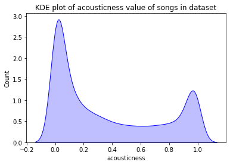

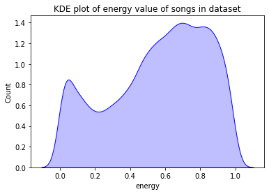

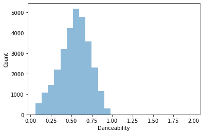

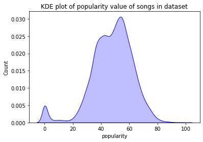

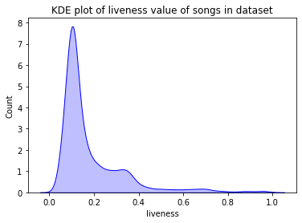

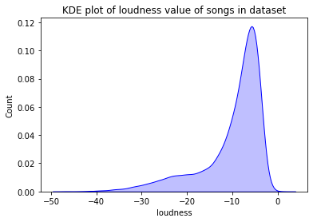

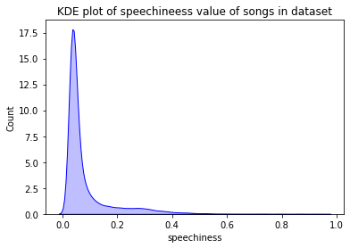

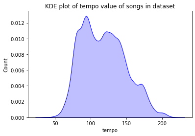

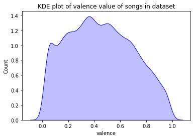

```python
ax = sns.kdeplot(dataset.acousticness, shade=True, color = "b")
plt.title("KDE plot of acousticness value of songs in dataset")
plt.ylabel("Count")
plt.show()

ax = sns.kdeplot(dataset.energy, shade=True, color = "b")
plt.title("KDE plot of energy value of songs in dataset")
plt.ylabel("Count")
plt.show()

plt.hist(dataset.danceability, range=(dataset.danceability.min(),
     dataset.danceability.max() + 1), bins = 25, alpha=0.5)
plt.xlabel("Danceability")
plt.ylabel("Count")
plt.show()

ax = sns.kdeplot(dataset.popularity, shade=True, color = "b")
plt.title("KDE plot of popularity value of songs in dataset")
plt.ylabel("Count")
plt.show()

ax = sns.kdeplot(dataset.liveness, shade=True, color = "b")
plt.title("KDE plot of liveness value of songs in dataset")
plt.ylabel("Count")
plt.show()

ax = sns.kdeplot(dataset.loudness, shade=True, color = "b")
plt.title("KDE plot of loudness value of songs in dataset")
plt.ylabel("Count")
plt.show()

ax = sns.kdeplot(dataset.speechiness, shade=True, color = "b")
plt.title("KDE plot of speechineess value of songs in dataset")
plt.ylabel("Count")
plt.show()

ax = sns.kdeplot(dataset.tempo, shade=True, color = "b")
plt.title("KDE plot of tempo value of songs in dataset")
plt.ylabel("Count")
plt.show()

ax = sns.kdeplot(dataset.valence, shade=True, color = "b")
plt.title("KDE plot of valence value of songs in dataset")
plt.ylabel("Count")
plt.show()
```

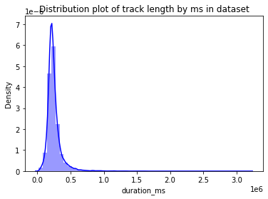

```python
ax = sns.distplot(dataset.duration_ms, hist=True, color="b")
plt.title("Distribution plot of track length by ms in dataset")
plt.ylabel("Density")
```

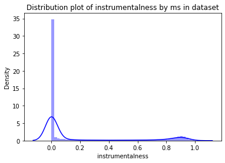

```python
ax = sns.distplot(dataset.instrumentalness, hist=True, color="b")
plt.title("Distribution plot of instrumentalness by ms in dataset")
plt.ylabel("Density")
```

Plots for categorical values

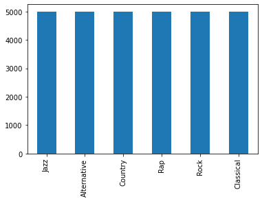

```python
dataset.music_genre.value_counts().plot.bar()
```

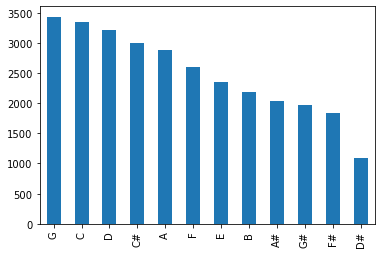

```python
dataset.key.value_counts().plot.bar()
```

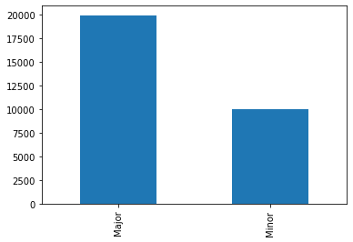

```python
dataset['mode'].value_counts().plot.bar()
```

Phase 1 P1-Q1 There are two general ways of dealing with missing data: 1-Removing entire row This solution keeps the data valid, but it takes away possibly useful samples by deleting an entire row because of one missing value. If there are a large amount of missing data in some of our weaker features, that could possibly be dropped in the future, removing the row damages our dataset with no benefits.

2- Replacing nan with value (usually column average) This solution keeps our dataset at its original size, and doesn't remove unrelated values due to one cell missing. But replacing a missing data with median or mean reduces our dataset's variability, which in future makes our classifiers less scalable and more prone to overfitting

```python
#phase 1
dataset.info()
```

```
<class 'pandas.core.frame.DataFrame'>
RangeIndex: 30000 entries, 0 to 29999
Data columns (total 16 columns):
 #   Column            Non-Null Count  Dtype
---  ------            --------------  -----
 0   artist_name       28506 non-null  object
 1   track_name        30000 non-null  object
 2   popularity        30000 non-null  float64
 3   acousticness      30000 non-null  float64
 4   danceability      30000 non-null  float64
 5   duration_ms       26990 non-null  float64
 6   energy            30000 non-null  float64
 7   instrumentalness  30000 non-null  float64
 8   key               30000 non-null  object
 9   liveness          30000 non-null  float64
 10  loudness          30000 non-null  float64
 11  mode              30000 non-null  object
 12  speechiness       30000 non-null  float64
 13  tempo             27067 non-null  float64
 14  valence           30000 non-null  float64
 15  music_genre       30000 non-null  object
dtypes: float64(11), object(5)
memory usage: 3.7+ MB
```

```python
dataset.duration_ms.fillna(dataset.duration_ms.mean(), inplace=True)
dataset.duration_ms.head()
```

```
0    285987.000000
1    103703.000000
2    246646.049722
3    228733.000000
4    342867.000000
Name: duration_ms, dtype: float64
```

Here I replaced the missing values with median because the distribution had a lot of variance.

```python
dataset.tempo.fillna(dataset.tempo.median(), inplace=True)
dataset.info()
```

```
<class 'pandas.core.frame.DataFrame'>
RangeIndex: 30000 entries, 0 to 29999
Data columns (total 16 columns):
 #   Column            Non-Null Count  Dtype
---  ------            --------------  -----
 0   artist_name       28506 non-null  object
 1   track_name        30000 non-null  object
 2   popularity        30000 non-null  float64
 3   acousticness      30000 non-null  float64
 4   danceability      30000 non-null  float64
 5   duration_ms       30000 non-null  float64
 6   energy            30000 non-null  float64
 7   instrumentalness  30000 non-null  float64
 8   key               30000 non-null  object
 9   liveness          30000 non-null  float64
 10  loudness          30000 non-null  float64
 11  mode              30000 non-null  object
 12  speechiness       30000 non-null  float64
 13  tempo             30000 non-null  float64
 14  valence           30000 non-null  float64
 15  music_genre       30000 non-null  object
dtypes: float64(11), object(5)
memory usage: 3.7+ MB
```

P1-Q3 Standardization and normalization are used to feature scale. This is done to avoid our algorithms being biased towards a feature with large values, as all features should be given equal importance.

Normalization transforms our features to be on a similar scale. This is usually done usin Min-Max Scaling, which scales all features into the [0,1] range, or [-1,1] if there are negative values.

Standardization transforms our features by subtracting from mean and dividing by standard deviation. This ensure that all features have a mean of 0 and a standard deviation of 1.

Normalization is more useful in machine learning algorithms that do not make assumptions about our data like k-nearest neighbors and neural networks.

Standardization is good to use when our data follows a normal distribution, it can be used in an algorithm where we make assumptions about the distribution like linear regression.

........ P1-Q3- I chose to MinMaxNormalize data for 2 reasons: 1-a number of the features didn't have a Gausian distribution, and had high variance: popularity, acousticness, instrumentalness, mode

2- the classifiers we use don't make assumptions about distributions so Normalization is more suited here.

P1-Q5 Binary Feature Encoding: This method is used for features that have only two values. Like a lamp being 'On' or 'Off'. Encoding these features is simple, we assign 0 to one value and 1 to the other.

Ordinal Feature Encoding: If our categorical featurs have an associated order, like school grades that start from 'F' and end at 'A', we can encode them by assigning (1,n) to the values in their order.

Here I used binary feature encoding for feature 'mode', because it had only two values 'Major' and 'Minor'. And I used Ordinal Encoding for feature 'key', as musical keys have a defined order.

I didn't encode the other two values because I removed them from the dataset, as explained in the next question.

```python
dataset['mode'].replace({'Major': 1, 'Minor': 0}, inplace=True)
```

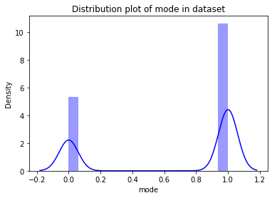

```python
ax = sns.distplot(dataset['mode'], hist=True, color="b")
plt.title("Distribution plot of mode in dataset")
plt.ylabel("Density")
```

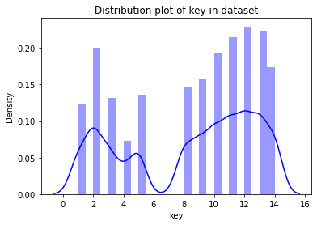

```python
from sklearn.preprocessing import LabelEncoder
label_encoder = LabelEncoder()
key_order = {'F#': 1, 'C#':2, 'G#': 3, 'D#': 4, 'A#': 5,
 'E#': 6, 'B#': 7, 'B': 8, 'E': 9, 'A': 10, 'D': 11, 'G': 12, 'C': 13, 'F': 14}
dataset.key = dataset.key.map(key_order)
ax = sns.distplot(dataset.key, hist=True, color="b")
plt.title("Distribution plot of key in dataset")
plt.ylabel("Density")
```

P1-Q6 We can't encode the names in any useful way, because the valuable data is the genre which the artist sings in.

What we can do is to find the main genre which the artist songs are categorized in, or mode, and replace the artist_name with their main genre.

```python
music_genre = dataset.music_genre
```

```python
dataset.dropna(subset=['artist_name'], inplace=True)
artist_names = dataset.artist_name.unique()
artist_main_genre = [dataset.music_genre.where(dataset.artist_name == d).mode().iloc[0] for d in artist_names]
artist_main_genre_dict = dict(zip(artist_names, artist_main_genre))
dataset.replace({'artist_name' : artist_main_genre_dict}, inplace=True)

dataset.rename(columns={'artist_name':'artist_main_genre'}, inplace=True)
```

```python
music_genre = dataset.music_genre
dataset.drop(labels = ['music_genre', 'track_name'], inplace=True, axis=1)
dataset = pd.get_dummies(dataset)
dataset.describe()
```

|  | popularity | acousticness | danceability | duration_ms | energy | instrumentalness | key | liveness | loudness | mode | speechiness | tempo | valence | artist_main_genre_Alternative | artist_main_genre_Classical | artist_main_genre_Country | artist_main_genre_Jazz | artist_main_genre_Rap | artist_main_genre_Rock |
| --- | --- | --- | --- | --- | --- | --- | --- | --- | --- | --- | --- | --- | --- | --- | --- | --- | --- | --- | --- |
| count | 28506.000000 | 28506.000000 | 28506.000000 | 2.850600e+04 | 28506.000000 | 28506.000000 | 28506.000000 | 28506.000000 | 28506.000000 | 28506.000000 | 28506.000000 | 28506.000000 | 28506.000000 | 28506.000000 | 28506.000000 | 28506.000000 | 28506.000000 | 28506.000000 | 28506.000000 |
| mean | 47.758998 | 0.359350 | 0.541178 | 2.464584e+05 | 0.556956 | 0.180622 | 8.428050 | 0.183806 | -10.070070 | 0.666000 | 0.083689 | 117.379295 | 0.446552 | 0.213113 | 0.167088 | 0.189469 | 0.168245 | 0.148460 | 0.113625 |
| std | 14.500065 | 0.363886 | 0.181765 | 1.066307e+05 | 0.277402 | 0.329169 | 4.296121 | 0.150905 | 6.943159 | 0.471648 | 0.093033 | 29.199711 | 0.248638 | 0.409514 | 0.373061 | 0.391888 | 0.374091 | 0.355562 | 0.317361 |
| min | 0.000000 | 0.000001 | 0.059600 | 1.550900e+04 | 0.000792 | 0.000000 | 1.000000 | 0.015700 | -47.046000 | 0.000000 | 0.022300 | 34.347000 | 0.000000 | 0.000000 | 0.000000 | 0.000000 | 0.000000 | 0.000000 | 0.000000 |
| 25% | 39.000000 | 0.029500 | 0.424000 | 1.946208e+05 | 0.362000 | 0.000000 | 4.000000 | 0.095900 | -12.053750 | 0.000000 | 0.035000 | 94.519250 | 0.243000 | 0.000000 | 0.000000 | 0.000000 | 0.000000 | 0.000000 | 0.000000 |
| 50% | 49.000000 | 0.205000 | 0.553000 | 2.327730e+05 | 0.602000 | 0.000087 | 10.000000 | 0.122000 | -7.618000 | 1.000000 | 0.045100 | 115.491000 | 0.435000 | 0.000000 | 0.000000 | 0.000000 | 0.000000 | 0.000000 | 0.000000 |
| 75% | 57.000000 | 0.708000 | 0.671000 | 2.648545e+05 | 0.785000 | 0.125000 | 12.000000 | 0.222000 | -5.430000 | 1.000000 | 0.079900 | 136.105000 | 0.639000 | 0.000000 | 0.000000 | 0.000000 | 0.000000 | 0.000000 | 0.000000 |
| max | 99.000000 | 0.996000 | 0.977000 | 3.195440e+06 | 0.998000 | 0.994000 | 14.000000 | 0.996000 | 1.342000 | 1.000000 | 0.941000 | 219.331000 | 0.985000 | 1.000000 | 1.000000 | 1.000000 | 1.000000 | 1.000000 | 1.000000 |

```python
from sklearn.preprocessing import MinMaxScaler, StandardScaler
scaler = MinMaxScaler()
```

Here we do the minMaxScaling

```python
dataset = pd.DataFrame(scaler.fit_transform(dataset.values), columns=dataset.columns, index=dataset.index)
dataset.describe()
```

|  | popularity | acousticness | danceability | duration_ms | energy | instrumentalness | key | liveness | loudness | mode | speechiness | tempo | valence | artist_main_genre_Alternative | artist_main_genre_Classical | artist_main_genre_Country | artist_main_genre_Jazz | artist_main_genre_Rap | artist_main_genre_Rock |
| --- | --- | --- | --- | --- | --- | --- | --- | --- | --- | --- | --- | --- | --- | --- | --- | --- | --- | --- | --- |
| count | 28506.000000 | 28506.000000 | 28506.000000 | 28506.000000 | 28506.000000 | 28506.000000 | 28506.000000 | 28506.000000 | 28506.000000 | 28506.000000 | 28506.000000 | 28506.000000 | 28506.000000 | 28506.000000 | 28506.000000 | 28506.000000 | 28506.000000 | 28506.000000 | 28506.000000 |
| mean | 0.482414 | 0.360792 | 0.524938 | 0.072627 | 0.557721 | 0.181712 | 0.571388 | 0.171484 | 0.764155 | 0.666000 | 0.066822 | 0.448862 | 0.453352 | 0.213113 | 0.167088 | 0.189469 | 0.168245 | 0.148460 | 0.113625 |
| std | 0.146465 | 0.365348 | 0.198131 | 0.033532 | 0.278179 | 0.331156 | 0.330471 | 0.153938 | 0.143489 | 0.471648 | 0.101266 | 0.157850 | 0.252425 | 0.409514 | 0.373061 | 0.391888 | 0.374091 | 0.355562 | 0.317361 |
| min | 0.000000 | 0.000000 | 0.000000 | 0.000000 | 0.000000 | 0.000000 | 0.000000 | 0.000000 | 0.000000 | 0.000000 | 0.000000 | 0.000000 | 0.000000 | 0.000000 | 0.000000 | 0.000000 | 0.000000 | 0.000000 | 0.000000 |
| 25% | 0.393939 | 0.029617 | 0.397210 | 0.056326 | 0.362219 | 0.000000 | 0.230769 | 0.081812 | 0.723160 | 0.000000 | 0.013824 | 0.325284 | 0.246701 | 0.000000 | 0.000000 | 0.000000 | 0.000000 | 0.000000 | 0.000000 |
| 50% | 0.494949 | 0.205822 | 0.537824 | 0.068323 | 0.602891 | 0.000087 | 0.692308 | 0.108436 | 0.814830 | 1.000000 | 0.024818 | 0.438654 | 0.441624 | 0.000000 | 0.000000 | 0.000000 | 0.000000 | 0.000000 | 0.000000 |
| 75% | 0.575758 | 0.710843 | 0.666449 | 0.078412 | 0.786404 | 0.125755 | 0.846154 | 0.210446 | 0.860048 | 1.000000 | 0.062697 | 0.550091 | 0.648731 | 0.000000 | 0.000000 | 0.000000 | 0.000000 | 0.000000 | 0.000000 |
| max | 1.000000 | 1.000000 | 1.000000 | 1.000000 | 1.000000 | 1.000000 | 1.000000 | 1.000000 | 1.000000 | 1.000000 | 1.000000 | 1.000000 | 1.000000 | 1.000000 | 1.000000 | 1.000000 | 1.000000 | 1.000000 | 1.000000 |

P1-Q7 Information gain

```
<class 'pandas.core.frame.DataFrame'>
Int64Index: 28506 entries, 0 to 29999
Data columns (total 19 columns):
 #   Column                         Non-Null Count  Dtype
---  ------                         --------------  -----
 0   popularity                     28506 non-null  float64
 1   acousticness                   28506 non-null  float64
 2   danceability                   28506 non-null  float64
 3   duration_ms                    28506 non-null  float64
 4   energy                         28506 non-null  float64
 5   instrumentalness               28506 non-null  float64
 6   key                            28506 non-null  float64
 7   liveness                       28506 non-null  float64
 8   loudness                       28506 non-null  float64
 9   mode                           28506 non-null  float64
 10  speechiness                    28506 non-null  float64
 11  tempo                          28506 non-null  float64
 12  valence                        28506 non-null  float64
 13  artist_main_genre_Alternative  28506 non-null  float64
 14  artist_main_genre_Classical    28506 non-null  float64
 15  artist_main_genre_Country      28506 non-null  float64
 16  artist_main_genre_Jazz         28506 non-null  float64
 17  artist_main_genre_Rap          28506 non-null  float64
 18  artist_main_genre_Rock         28506 non-null  float64
dtypes: float64(19)
memory usage: 4.3 MB
```

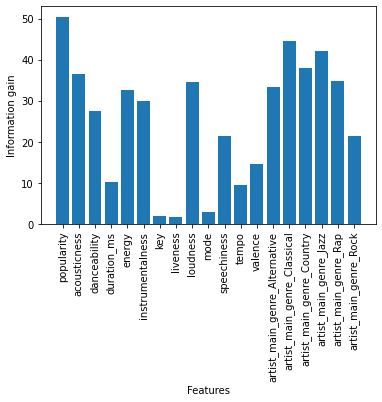

```python
from sklearn.feature_selection import mutual_info_classif
dataset.info()
feature_scores = mutual_info_classif(dataset, music_genre) * 100
feature_scores_df = pd.DataFrame(feature_scores.reshape(1,-1), columns=dataset.columns)
feature_scores_df


plt.bar(feature_scores_df.columns, feature_scores)
plt.xlabel("Features")
plt.ylabel("Information gain")
plt.xticks(rotation='vertical')
plt.show()
```

P1-Q7 No. As we can see in the information gain chart, some of the feature, like 'key'-'liveness'-'mode' have virtually no relevance to the result.

Keeping all features would marginally improve algorithm accuracy, but that accuracy gain wouldn't be worth the magnitudes in which the algorithm execution would increace by. Reducing features would also help with avoiding overfitting

Removing some features might hurt accuracy and increase the possibility of underfitting. However it would reduce algorithm runtime and memory usage

Here we can remove columns 'key', 'liveness', 'mode', 'tempo' as they have under 10% information gain

```python
dataset.drop(labels=['key', 'liveness', 'mode', 'tempo'], inplace=True, axis=1)
dataset.info()
```

```
<class 'pandas.core.frame.DataFrame'>
Int64Index: 28506 entries, 0 to 29999
Data columns (total 15 columns):
 #   Column                         Non-Null Count  Dtype
---  ------                         --------------  -----
 0   popularity                     28506 non-null  float64
 1   acousticness                   28506 non-null  float64
 2   danceability                   28506 non-null  float64
 3   duration_ms                    28506 non-null  float64
 4   energy                         28506 non-null  float64
 5   instrumentalness               28506 non-null  float64
 6   loudness                       28506 non-null  float64
 7   speechiness                    28506 non-null  float64
 8   valence                        28506 non-null  float64
 9   artist_main_genre_Alternative  28506 non-null  float64
 10  artist_main_genre_Classical    28506 non-null  float64
 11  artist_main_genre_Country      28506 non-null  float64
 12  artist_main_genre_Jazz         28506 non-null  float64
 13  artist_main_genre_Rap          28506 non-null  float64
 14  artist_main_genre_Rock         28506 non-null  float64
dtypes: float64(15)
memory usage: 3.5 MB
```

Phase 2 P2-Q1 I let the train_test_split choose the P by specifing the stratify parameter

Yes,Randomizing the split and shuffling the data before splitting helps us avoid overfitting, as the datas may have been gathered in a specific way.

It's not necessary but it's better. As unequal ratios could cause our algorithm to overfit

train_test_split: stratify is the desired ratio for each target data, given stratify the function will split our data in a way that the percentage of each target value is equal to its ratio in stratify

```python
#phase_02
from sklearn.model_selection import train_test_split
music_genre_val = label_encoder.fit_transform(music_genre)
X_train, X_test, y_train, y_test = train_test_split(dataset, music_genre, stratify=music_genre_val, random_state=42)
```

```python
from sklearn.neighbors import KNeighborsClassifier
knn = KNeighborsClassifier(n_neighbors=5)
```

```python
def plotEstimatorHyperparamterAccuracy(hyperparameter_array, train_accuracy_Scores, test_accuracy_scores, xlabel):
    plt.scatter(hyperparameter_array, train_accuracy_scores)
    plt.plot(hyperparameter_array, train_accuracy_scores)
    plt.xlabel(xlabel)
    plt.ylabel("Estimator accuracy on training data")
    plt.show()

    plt.scatter(hyperparameter_array, test_accuracy_scores)
    plt.plot(hyperparameter_array, test_accuracy_scores)
    plt.xlabel(xlabel)
    plt.ylabel("Estimator accuracy on test data")
    plt.show()

    plt.scatter(hyperparameter_array, train_accuracy_scores)
    plt.scatter(hyperparameter_array, test_accuracy_scores)
    plt.plot(hyperparameter_array, train_accuracy_scores)
    plt.plot(hyperparameter_array, test_accuracy_scores)
    plt.legend(["Train data", "Test data"], loc = "lower right")
    plt.xlabel(xlabel)
    plt.ylabel("Estimator accuracy")
    plt.show()
```

P2-Q3 We can see that KNN has over %98 training accuracy for n_neighbors = 1, which is a sign of overfitting, but this percentage goes down as we increase the parameter.

It's the other way round for test accuracy. It begins at under 85% for n_neighbors = 1, and it steadily goes up to ~91%. And it pleateus after n_neighbors = 25 as we hit diminishing returns

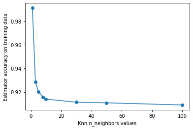

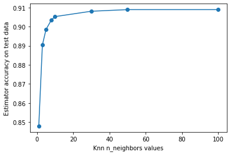

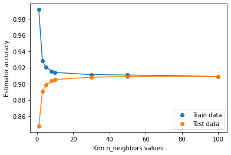

```python
knn_n_neighbors = [1, 3, 5, 8, 10, 30, 50, 100]
train_accuracy_scores = []
test_accuracy_scores = []
for k in knn_n_neighbors:
    knn = KNeighborsClassifier(n_neighbors=k)
    knn.fit(X_train, y_train)
    train_accuracy_scores.append(knn.score(X_train, y_train))
    test_accuracy_scores.append(knn.score(X_test, y_test))

plotEstimatorHyperparamterAccuracy(knn_n_neighbors, train_accuracy_scores, test_accuracy_scores, "Knn n_neighbors values")
```

```python
from sklearn.model_selection import RandomizedSearchCV
from scipy.stats import randint
knn_hyperparameters = {'n_neighbors': randint(1,100)}

random_knn = RandomizedSearchCV(estimator=knn, param_distributions=knn_hyperparameters)
random_knn.fit(X_train, y_train)

print(" Results from Random Search " )
print("\nTraining data accuracy:\n", random_knn.score(X_train, y_train))
print("\nTest data accuracy:\n", random_knn.score(X_test, y_test))
print("\n The best estimator across ALL searched params:\n", random_knn.best_estimator_)
print("\n The best score across ALL searched params:\n", random_knn.best_score_)
print("\n The best parameters across ALL searched params:\n", random_knn.best_params_)
```

```
 Results from Random Search

Training data accuracy:
 0.9114083914121334

Test data accuracy:
 0.9080959730601936

 The best estimator across ALL searched params:
 KNeighborsClassifier(n_neighbors=35)

 The best score across ALL searched params:
 0.9092098096816722

 The best parameters across ALL searched params:
 {'n_neighbors': 35}
```

P2-Q4 Optimizing Decision Tree classifier hyperparameters

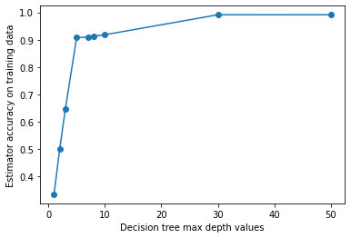

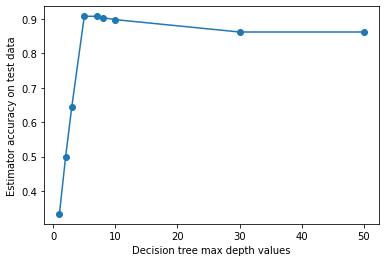

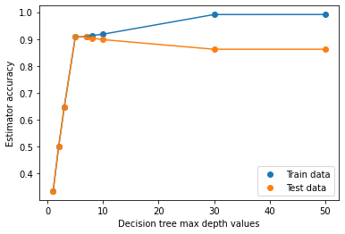

```python
from sklearn.tree import DecisionTreeClassifier
dt_max_depth = [1, 2, 3, 5, 7, 8, 10, 30, 50]
train_accuracy_scores = []
test_accuracy_scores = []
for depth in dt_max_depth:
    decision_tree_classifier = DecisionTreeClassifier(max_depth=depth, random_state=42)
    decision_tree_classifier.fit(X_train, y_train)
    train_accuracy_scores.append(decision_tree_classifier.score(X_train, y_train))
    test_accuracy_scores.append(decision_tree_classifier.score(X_test, y_test))

plotEstimatorHyperparamterAccuracy(dt_max_depth, train_accuracy_scores, test_accuracy_scores, "Decision tree max depth values")
```

P2-Q5

```python
dt_hyperparameters = {'max_depth': randint(1,50)}

random_dt = RandomizedSearchCV(estimator=decision_tree_classifier, param_distributions=dt_hyperparameters)
random_dt.fit(X_train, y_train)

print(" Results from Random Search " )
print("\nTraining data accuracy:\n", random_dt.score(X_train, y_train))
print("\nTest data accuracy:\n", random_dt.score(X_test, y_test))
print("\n The best estimator across ALL searched params:\n", random_dt.best_estimator_)
print("\n The best score across ALL searched params:\n", random_dt.best_score_)
print("\n The best parameters across ALL searched params:\n", random_dt.best_params_)
```

```
 Results from Random Search

Training data accuracy:
 0.9126713129706722

Test data accuracy:
 0.9033253823488143

 The best estimator across ALL searched params:
 DecisionTreeClassifier(max_depth=8, random_state=42)

 The best score across ALL searched params:
 0.9044855934660474

 The best parameters across ALL searched params:
 {'max_depth': 8}
```

P2-Q5 Overfitting: when a model learn the details in the training data to the extent that hurts its performance on test data

Underfitting: A model that can neither predict the training data nor the test data. An underfit machine is easy to detect as it will have poor performance on the training data

Our two classifiers with their best parameters haven't underfit nor overfit on the data, as they can predict the target with over 90% accuracy on both sets of input

```python
from sklearn.metrics import classification_report, confusion_matrix
def printClassifierMetrics(classifier, classifierName):
    print("{} evaluation metrics on training data:\n{}".format(classifierName, classification_report(y_true=y_train, y_pred=classifier.predict(X_train))))
    print("accuracy on training data: {}\n".format(classifier.score(X_train, y_train)))
    print("{} evaluation metrics on test data:\n{}".format(classifierName, classification_report(y_true=y_test, y_pred=classifier.predict(X_test))))
    print("accuracy on test data: {}\n".format(classifier.score(X_test, y_test)))
```

P2-Q6 Precision: number of correct positive predictions made. This metric calculates the classifier accuracy for a specific class. Maximising precision is important when we're focusing on minimizing false positives.

Recall: number of correct positive predicitions out of all possible positive predictions. So while precision only looks at the positive predictions, recall provides an indication of missed positive predictions (or false negatives). Maximising precision is important when we're focusing on minimizing false negatives.

F-Measure or F1-Score: this metric combines both precision and recall into a single measure that captures both properties.

We can have excellent precision with terrible recall, or alternately, terrible precision with excellent recall. F-measure provides a way to express both concerns with a single score.

F1-Score is usually calculated using the below formula: F1-Score = (2 *Precision* Recall) / (Precision + Recall)

Accuracy: number of correct predictions divided by the total number of samples.

```python
knn = KNeighborsClassifier(n_neighbors=26)
knn.fit(X_train, y_train)
printClassifierMetrics(knn, "K nearest neighbors classifier")
```

```
K nearest neighbors classifier evaluation metrics on training data:
              precision    recall  f1-score   support

 Alternative       0.78      0.92      0.84      3546
   Classical       0.99      1.00      1.00      3551
     Country       0.87      0.98      0.92      3584
        Jazz       0.98      0.99      0.99      3577
         Rap       0.98      0.89      0.93      3553
        Rock       0.90      0.70      0.78      3568

    accuracy                           0.91     21379
   macro avg       0.92      0.91      0.91     21379
weighted avg       0.92      0.91      0.91     21379

accuracy on training data: 0.9116890406473642

K nearest neighbors classifier evaluation metrics on test data:
              precision    recall  f1-score   support

 Alternative       0.77      0.90      0.83      1182
   Classical       0.99      1.00      1.00      1183
     Country       0.87      0.98      0.92      1195
        Jazz       0.98      0.99      0.99      1193
         Rap       0.98      0.88      0.93      1184
        Rock       0.89      0.70      0.78      1190

    accuracy                           0.91      7127
   macro avg       0.91      0.91      0.91      7127
weighted avg       0.91      0.91      0.91      7127

accuracy on test data: 0.9089378420092605
```

```python
decision_tree_classifier = DecisionTreeClassifier(max_depth=11)
decision_tree_classifier.fit(X_train, y_train)
printClassifierMetrics(decision_tree_classifier, "Decision tree classifier")
```

```
Decision tree classifier evaluation metrics on training data:
              precision    recall  f1-score   support

 Alternative       0.86      0.86      0.86      3546
   Classical       1.00      1.00      1.00      3551
     Country       0.89      0.98      0.93      3584
        Jazz       1.00      0.99      0.99      3577
         Rap       0.97      0.92      0.94      3553
        Rock       0.84      0.80      0.82      3568

    accuracy                           0.92     21379
   macro avg       0.92      0.92      0.92     21379
weighted avg       0.92      0.92      0.92     21379

accuracy on training data: 0.9236166331446747

Decision tree classifier evaluation metrics on test data:
              precision    recall  f1-score   support

 Alternative       0.80      0.82      0.81      1182
   Classical       0.99      0.99      0.99      1183
     Country       0.87      0.96      0.91      1195
        Jazz       0.98      0.98      0.98      1193
         Rap       0.96      0.89      0.92      1184
        Rock       0.80      0.75      0.78      1190

    accuracy                           0.90      7127
   macro avg       0.90      0.90      0.90      7127
weighted avg       0.90      0.90      0.90      7127

accuracy on test data: 0.8985547916374351
```

Phase 3 Random Forest P3-Q1 Implementing using sklearn P3-Q2 Tuning the parameters and plotting the accuracy

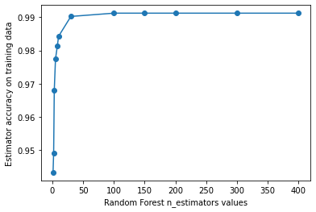

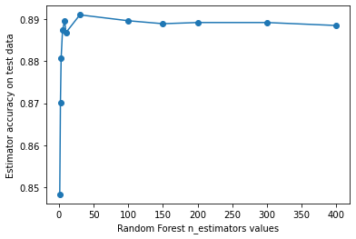

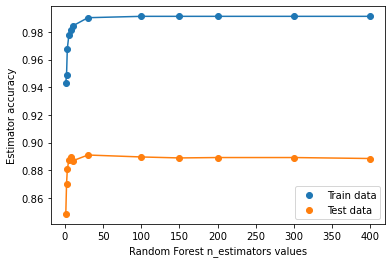

```python
#phase 03
from sklearn.ensemble import RandomForestClassifier
number_of_trees = [1, 2, 3, 5, 8, 10, 30, 100, 150, 200, 300, 400]
train_accuracy_scores = []
test_accuracy_scores = []

for n in number_of_trees:
    random_forest_classifier = RandomForestClassifier(n_estimators=n)
    random_forest_classifier.fit(X_train, y_train)
    train_accuracy_scores.append(random_forest_classifier.score(X_train, y_train))
    test_accuracy_scores.append(random_forest_classifier.score(X_test, y_test))

plotEstimatorHyperparamterAccuracy(number_of_trees, train_accuracy_scores, test_accuracy_scores, "Random Forest n_estimators values")
```

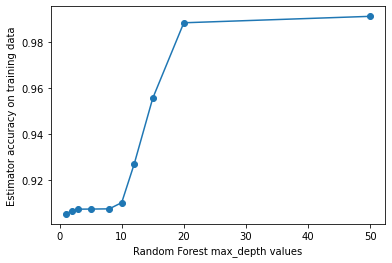

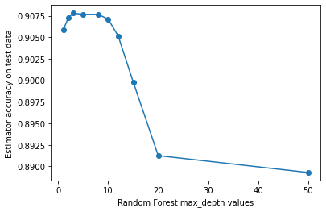

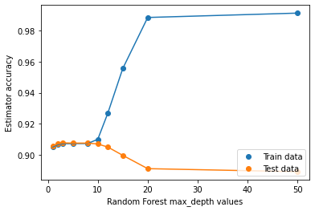

```python
rf_max_depth = [1, 2, 3, 5, 8, 10, 12, 15, 20, 50]
train_accuracy_scores = []
test_accuracy_scores = []

for m in rf_max_depth:
    random_forest_classifier = RandomForestClassifier(n_estimators=150, max_depth=m, random_state=42)
    random_forest_classifier.fit(X_train, y_train)
    train_accuracy_scores.append(random_forest_classifier.score(X_train, y_train))
    test_accuracy_scores.append(random_forest_classifier.score(X_test, y_test))

plotEstimatorHyperparamterAccuracy(rf_max_depth, train_accuracy_scores, test_accuracy_scores, "Random Forest max_depth values")
```

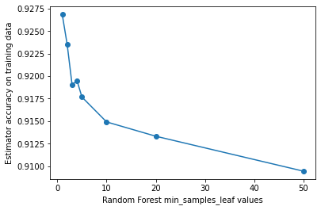

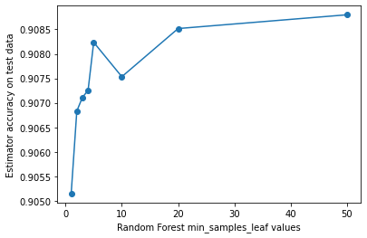

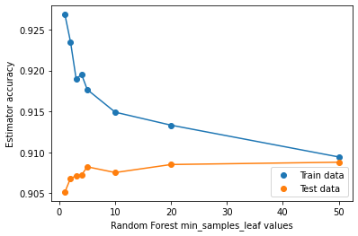

```python
min_samples_leaf_values = [1, 2, 3, 4, 5, 10, 20, 50]
train_accuracy_scores = []
test_accuracy_scores = []

for m in min_samples_leaf_values:
    random_forest_classifier = RandomForestClassifier(n_estimators=150, max_depth=12, min_samples_leaf=m, random_state=42)
    random_forest_classifier.fit(X_train, y_train)
    train_accuracy_scores.append(random_forest_classifier.score(X_train, y_train))
    test_accuracy_scores.append(random_forest_classifier.score(X_test, y_test))

plotEstimatorHyperparamterAccuracy(min_samples_leaf_values, train_accuracy_scores, test_accuracy_scores, "Random Forest min_samples_leaf values")
```

P3-Q3 Classifier evaluation using the 4 metrics

```python
from sklearn.model_selection import RandomizedSearchCV
from scipy.stats import randint
random_forest_classifier = RandomForestClassifier()
rf_hyperparameters = {'n_estimators': randint(1,500), 'min_samples_leaf' : randint(1,60)}

random_rf = RandomizedSearchCV(estimator=random_forest_classifier, param_distributions=rf_hyperparameters)
random_rf.fit(X_train, y_train)

print(" Results from Random Search " )
print("\nTraining data accuracy:\n", random_rf.score(X_train, y_train))
print("\nTest data accuracy:\n", random_rf.score(X_test, y_test))
print("\n The best estimator across ALL searched params:\n", random_rf.best_estimator_)
print("\n The best score across ALL searched params:\n", random_rf.best_score_)
print("\n The best parameters across ALL searched params:\n", random_rf.best_params_)
```

```
 Results from Random Search

Training data accuracy:
 0.9187052715281351

Test data accuracy:
 0.9079556615686825

 The best estimator across ALL searched params:
 RandomForestClassifier(min_samples_leaf=19, n_estimators=216)

 The best score across ALL searched params:
 0.9082742793997779

 The best parameters across ALL searched params:
 {'min_samples_leaf': 19, 'n_estimators': 216}
```

```python
random_forest_classifier = RandomForestClassifier(min_samples_leaf=8, max_depth=150, n_estimators=476)
random_forest_classifier.fit(X_train, y_train)
printClassifierMetrics(random_forest_classifier, "Random Forest classifer")
```

```
Random Forest classifer evaluation metrics on training data:
              precision    recall  f1-score   support

 Alternative       0.84      0.93      0.88      3546
   Classical       0.99      1.00      1.00      3551
     Country       0.87      0.98      0.93      3584
        Jazz       0.98      0.99      0.99      3577
         Rap       0.99      0.89      0.94      3553
        Rock       0.92      0.78      0.84      3568

    accuracy                           0.93     21379
   macro avg       0.93      0.93      0.93     21379
weighted avg       0.93      0.93      0.93     21379

accuracy on training data: 0.9289489686140605

Random Forest classifer evaluation metrics on test data:
              precision    recall  f1-score   support

 Alternative       0.77      0.88      0.82      1182
   Classical       0.99      1.00      1.00      1183
     Country       0.87      0.98      0.92      1195
        Jazz       0.98      0.99      0.99      1193
         Rap       0.99      0.88      0.93      1184
        Rock       0.86      0.70      0.77      1190

    accuracy                           0.91      7127
   macro avg       0.91      0.91      0.90      7127
weighted avg       0.91      0.91      0.90      7127

accuracy on test data: 0.9058509891960151
```

P3-Q4 The confusion matrix This cell i,j in this matrix shows the number of predictions with true label being i_th class and predicted label being j_th class

```python
confusion_matrix(y_true=y_test, y_pred=random_forest_classifier.predict(X_test))
```

```
array([[1040,    0,   17,   16,    9,  100],
       [   0, 1183,    0,    0,    0,    0],
       [  12,    0, 1174,    0,    0,    9],
       [   2,    6,    2, 1183,    0,    0],
       [  88,    0,   23,    2, 1039,   32],
       [ 208,    1,  137,    3,    4,  837]], dtype=int64)
```